# Explore

This script required the loaded and part-recoded frames from `load.Rmd` - either `df_d1` or `df_f2`

```r
library(tidyverse)
library(ggplot2)
detach("package:dplyr")
library(dplyr)
library(lubridate)
```

Set the data (either from tank d1 or d2)

```r
df <- df_d1_prepped
# df <- df_f2_prepped
```

# Discretising `state` and `sp`

Have a closer look at `state`

```r
df %>%
  group_by(state) %>%
  count() %>%
  arrange(desc(n))

df %>%
  select(state) %>%
  summary()
```

Lets check if this makes sense:

```r
# Facet plot status and floored status
df %>%
  ggplot() +
    geom_line(aes(x = t_stamp, y = state), colour = "orange") +
    facet_wrap(vars(month), scales = "free_x")

# Facet plot status and floored status
df %>%
  ggplot() +
    geom_line(aes(x = t_stamp, y = eng, colour = "temp")) +
    geom_line(aes(x = t_stamp, y = sp, colour = "sp")) +
    scale_colour_manual("", breaks = c("temp", "sp"), values = c("grey", "pink")) +
    facet_wrap(vars(month), scales = "free")
```

Some issues here…

The key issue is that the extraction algo extracted the discrete `state` and `sp` variables as part continuous as it iinterpolated between values. In fact `sp` is continuous but it’s series should describe a step function. An example is June:

```r
month_selected <- "Jun"

plot1 <- df %>%
  filter(month == month_selected) %>%
  ggplot() +
    geom_line(aes(x = t_stamp, y = state, colour = "state")) +
    scale_colour_manual("", breaks = c("ceil", "state"), values = c("skyblue", "orange")) +
    scale_y_continuous(breaks = c(1,2,3)) +
    labs(y = "")

plot2 <- df %>%
  filter(month == month_selected) %>%
  ggplot() +
    geom_line(aes(x = t_stamp, y = eng, colour = "temp")) +
    geom_line(aes(x = t_stamp, y = sp, colour = "sp")) +
    scale_colour_manual("", breaks = c("temp", "sp"), values = c("grey", "pink")) +
    labs(y = "")

gridExtra::grid.arrange(plot1, plot2, nrow = 2)
```

Question: at what points was the state 1, 2 or 3? And at what times was the setpoint (`sp`) which value?

Answer: the answer is in the file

```
State and SP readings from
raw data.xlsx
```

which is an extract of all `state` and `sp` readings **when they changed** from the raw data.

Discussion: we should probably read these in and join them as a new variable. Alternatively, we could reverse-engineer the extraction algorithm, but it won’t be a simple floor or ceiling exercise of the variables. We will need to distinguish previous slopes from orthogonal data changes (as in the June `sp` example) and some values don’t go all the way up to integers like for example on the 29th of April at 18:30, which goes up to 2.999351:

```r
apr <- df %>%
  filter(t_stamp > lubridate::ymd("2021-04-29"), t_stamp < lubridate::ymd("2021-04-30"))

apr %>% View()

apr %>%
  ggplot() +
    geom_line(aes(x = t_stamp, y = state), colour = "skyblue")
```

Solution: in the file

```
State and SP readings from raw
data.xlsx
```

we prepare two sheets to join into the base file here. One sheet holds all discrete `state` and the other all `sp` values from the raw data matched to the *next* quarter hour (the values are by minute, but I assume the correct way of logging would be by the next quarter hour). Time duplicates in one quarter hour are indicated (the latest value is being taken):

```r
df <- df_d1_prepped

# Read in actual readings.
state_actual <- readxl::read_excel("../data/raw/D1/State and SP readings from raw data.xlsx", sheet = "state")
sp_actual <- readxl::read_excel("../data/raw/D1/State and SP readings from raw data.xlsx", sheet = "sp")

state_actual
```

| t_stamp | state_actual | remove_dupe |
| --- | --- | --- |
| 2021-02-23 16:30:00 | 1 | NA |
| 2021-02-25 18:15:00 | 1 | NA |
| 2021-02-25 23:30:00 | 1 | NA |
| 2021-02-26 00:30:00 | 3 | NA |
| 2021-03-06 02:15:00 | 2 | NA |
| 2021-04-28 21:30:00 | 2 | NA |
| 2021-04-29 02:30:00 | 2 | NA |
| 2021-04-30 01:45:00 | 3 | NA |
| 2021-04-30 15:00:00 | 2 | NA |
| 2021-05-04 19:15:00 | 2 | NA |

[output cut: 25 more lines]

```r
sp_actual
```

| t_stamp | sp_actual | remove_dupe |
| --- | --- | --- |
| 2021-01-05 14:15:00 | 0 | NA |
| 2021-01-13 20:00:00 | 55 | NA |
| 2021-01-28 18:45:00 | 0 | NA |
| 2021-01-29 01:15:00 | 55 | NA |
| 2021-02-08 19:45:00 | 0 | NA |
| 2021-02-10 14:15:00 | 55 | NA |
| 2021-02-23 16:30:00 | 0 | NA |
| 2021-02-25 18:15:00 | 0 | NA |
| 2021-02-25 23:30:00 | 0 | NA |
| 2021-02-26 00:30:00 | 55 | NA |

[output cut: 43 more lines]

```r
# Remove duplicates (keep the latest date/value - prepped in xls)
state_actual <- state_actual %>% filter(is.na(remove_dupe)) %>% select(-remove_dupe)
sp_actual <- sp_actual %>% filter(is.na(remove_dupe)) %>% select(-remove_dupe)

# Prep df (remove all actual values that might have been added previously)
df <- df %>%
  select(-starts_with("state_actual")) %>%
  select(-starts_with("sp_actual"))

# Join.
(df <- df %>%
  left_join(state_actual, by = "t_stamp") %>%
  left_join(sp_actual, by = "t_stamp"))
```

| t_stamp | year | month | day | wday | sp | eng | state | state_actual | sp_actual |
| --- | --- | --- | --- | --- | --- | --- | --- | --- | --- |
| 2021-01-01 00:00:00 | 2021 | Jan | 1 | Fri | 9.12678297 | 54.09678 | 2 | NA | NA |
| 2021-01-01 00:15:00 | 2021 | Jan | 1 | Fri | 9.10438585 | 54.08195 | 2 | NA | NA |
| 2021-01-01 00:30:00 | 2021 | Jan | 1 | Fri | 9.08198872 | 54.06711 | 2 | NA | NA |
| 2021-01-01 00:45:00 | 2021 | Jan | 1 | Fri | 9.05959160 | 54.05227 | 2 | NA | NA |
| 2021-01-01 01:00:00 | 2021 | Jan | 1 | Fri | 9.03719447 | 54.03744 | 2 | NA | NA |
| 2021-01-01 01:15:00 | 2021 | Jan | 1 | Fri | 9.01479735 | 54.02765 | 2 | NA | NA |
| 2021-01-01 01:30:00 | 2021 | Jan | 1 | Fri | 8.99240022 | 54.01572 | 2 | NA | NA |
| 2021-01-01 01:45:00 | 2021 | Jan | 1 | Fri | 8.97000310 | 54.00682 | 2 | NA | NA |
| 2021-01-01 02:00:00 | 2021 | Jan | 1 | Fri | 8.94760597 | 53.99792 | 2 | NA | NA |
| 2021-01-01 02:15:00 | 2021 | Jan | 1 | Fri | 8.92520884 | 53.98902 | 2 | NA | NA |

[output cut: 990 more lines]

```r
NA
```

All the non-set timepoints need to be filled, which happens in the following from **the value down**. The first value however is missing, which has been assumed by viewing the data:

```r
# Set first `state` value for `fill` to work (check with chart above)
df[1,]$state_actual = 2

# Set first `sp` value for `fill` to work (check with chart above and set the most likely value)
df[1,]$sp_actual = 55

# Fill the missing values (from top to bottom)
df <- df %>%
  fill(state_actual, .direction = "down") %>%
  fill(sp_actual, .direction = "down")
```

Check the solution:

```r
df %>%
  group_by(state_actual) %>%
  count()

df %>%
  group_by(sp_actual) %>%
  count()
```

```r
# Facet plot status and floored status
df %>%
  ggplot() +
    geom_line(aes(x = t_stamp, y = state, colour = "extracted")) +
    geom_line(aes(x = t_stamp, y = state_actual, colour = "actual")) +
    scale_colour_manual("", breaks = c("extracted", "actual"), values = c("orange", "skyblue")) +
    ylab("state") +
    facet_wrap(vars(month), scales = "free_x")

# Facet plot status and floored status
df %>%
  ggplot() +
    geom_line(aes(x = t_stamp, y = eng, colour = "temp")) +
    geom_line(aes(x = t_stamp, y = sp, colour = "extracted")) +
    geom_line(aes(x = t_stamp, y = sp_actual, colour = "actual")) +
    scale_colour_manual("", breaks = c("temp", "extracted", "actual"), values = c("grey", "pink", "skyblue")) +
    ylab("set point") +
    facet_wrap(vars(month), scales = "free_x")
```

Check period with missing actual `state` and `sp` data

There’s no `state` and `sp` data from 19/10/21. `state` values from this day can go to 0.5 and there’s still one `sp` value sloping up.

```r
check <- df %>%
  filter(t_stamp > ymd("2021-10-19"))

check %>% View()
```

## Checking `sp`:

```r
# The whole period
check %>%
  ggplot() +
    geom_line(aes(x = t_stamp, y = sp, colour = "extracted")) +
    geom_line(aes(x = t_stamp, y = sp_actual, colour = "actual")) +
    scale_colour_manual("", breaks = c("extracted", "actual"), values = c("pink", "skyblue")) +
    ylab("setpoint") +
    facet_wrap(vars(month), scales = "free_x")

# Check which numbers are in-between possible values
check %>%
  group_by(sp) %>%
  count() %>%
  arrange(desc(n)) %>%
  View()

# Result: slope between 19.10 and

# The October fun
check %>%
  filter(t_stamp > ymd_h("2021-10-01 0"), t_stamp < ymd_h("2021-10-31 0")) %>%
  ggplot() +
    geom_line(aes(x = t_stamp, y = sp, colour = "extracted")) +
    geom_line(aes(x = t_stamp, y = sp_actual, colour = "actual")) +
    scale_colour_manual("", breaks = c("extracted", "actual"), values = c("pink", "skyblue")) +
    ylab("setpoint") +
    facet_wrap(vars(month), scales = "free_x")
```

The slope from 19.10 moves to **2021-10-26 18:00:00** exactly. Assuming the extraction logic to be responsible for the slope, we’ll take `sp_actual` up to Oct 26 and then switch to `sp`.

```r
# Check all.
df %>%
  mutate(sp_final = ifelse(t_stamp > ymd_hms("2021-10-26 18:00:00"), sp, sp_actual)) %>%
  ggplot() +
    geom_line(aes(x = t_stamp, y = sp, colour = "extracted")) +
    geom_line(aes(x = t_stamp, y = sp_actual, colour = "actual")) +
    geom_line(aes(x = t_stamp, y = sp_final, colour = "final")) +
    scale_colour_manual("", breaks = c("extracted", "actual", "final"), values = c("pink", "skyblue", "grey")) +
    ylab("setpoint") +
    facet_wrap(vars(month), scales = "free_x")

# Double check key months.
p1 <- df %>%
  mutate(sp_final = ifelse(t_stamp > ymd_hms("2021-10-26 18:00:00"), sp, sp_actual)) %>%
  filter(month == "Oct" | month == "Nov" | month == "Dec") %>%
  ggplot() +
    geom_line(aes(x = t_stamp, y = sp, colour = "extracted")) +
    geom_line(aes(x = t_stamp, y = sp_actual, colour = "actual")) +
    geom_line(aes(x = t_stamp, y = sp_final, colour = "final")) +
    scale_colour_manual("", breaks = c("extracted", "actual", "final"), values = c("pink", "skyblue", "grey")) +
    ylab("setpoint") +
    facet_wrap(vars(month), scales = "free_x")

p2 <- df %>%
  mutate(sp_final = ifelse(t_stamp > ymd_hms("2021-10-26 18:00:00"), sp, sp_actual)) %>%
  filter(month == "Oct" | month == "Nov" | month == "Dec") %>%
  ggplot() +
    geom_line(aes(x = t_stamp, y = sp, colour = "extracted")) +
    geom_line(aes(x = t_stamp, y = sp_actual, colour = "actual")) +
    scale_colour_manual("", breaks = c("extracted", "actual", "final"), values = c("pink", "skyblue", "grey")) +
    ylab("setpoint") +
    facet_wrap(vars(month), scales = "free_x")

gridExtra::grid.arrange(p1, p2, nrow = 2)
```

Yep, do it:

```r
(df <- df %>%
  mutate(sp_final = ifelse(t_stamp > ymd_hms("2021-10-26 18:00:00"), sp, sp_actual)))
```

| t_stamp | year | month | day | wday | sp | eng | state | state_actual | sp_actual | sp_final |
| --- | --- | --- | --- | --- | --- | --- | --- | --- | --- | --- |
| 2021-01-01 00:00:00 | 2021 | Jan | 1 | Fri | 9.12678297 | 54.09678 | 2 | 2 | 55 | 55 |
| 2021-01-01 00:15:00 | 2021 | Jan | 1 | Fri | 9.10438585 | 54.08195 | 2 | 2 | 55 | 55 |
| 2021-01-01 00:30:00 | 2021 | Jan | 1 | Fri | 9.08198872 | 54.06711 | 2 | 2 | 55 | 55 |
| 2021-01-01 00:45:00 | 2021 | Jan | 1 | Fri | 9.05959160 | 54.05227 | 2 | 2 | 55 | 55 |
| 2021-01-01 01:00:00 | 2021 | Jan | 1 | Fri | 9.03719447 | 54.03744 | 2 | 2 | 55 | 55 |
| 2021-01-01 01:15:00 | 2021 | Jan | 1 | Fri | 9.01479735 | 54.02765 | 2 | 2 | 55 | 55 |
| 2021-01-01 01:30:00 | 2021 | Jan | 1 | Fri | 8.99240022 | 54.01572 | 2 | 2 | 55 | 55 |
| 2021-01-01 01:45:00 | 2021 | Jan | 1 | Fri | 8.97000310 | 54.00682 | 2 | 2 | 55 | 55 |
| 2021-01-01 02:00:00 | 2021 | Jan | 1 | Fri | 8.94760597 | 53.99792 | 2 | 2 | 55 | 55 |
| 2021-01-01 02:15:00 | 2021 | Jan | 1 | Fri | 8.92520884 | 53.98902 | 2 | 2 | 55 | 55 |

[output cut: 990 more lines]

```r
NA
```

## Checking `state`:

```r
# The whole period
check %>%
  ggplot() +
    geom_line(aes(x = t_stamp, y = state, colour = "extracted")) +
    geom_line(aes(x = t_stamp, y = state_actual, colour = "actual")) +
    scale_colour_manual("", breaks = c("extracted", "actual"), values = c("orange", "skyblue")) +
    ylab("state") +
    facet_wrap(vars(month), scales = "free_x")

# Check which numbers are in-between possible values
check %>%
  group_by(state) %>%
  count() %>%
  arrange(desc(n))

# Result: no values between 1 and 2 but many values between 2 and 3

# The October fun
check %>%
  filter(t_stamp > ymd_h("2021-10-23 18"), t_stamp < ymd_h("2021-10-26 18")) %>%
  ggplot() +
    geom_line(aes(x = t_stamp, y = state, colour = "extracted")) +
    geom_line(aes(x = t_stamp, y = state_actual, colour = "actual")) +
    scale_colour_manual("", breaks = c("extracted", "actual"), values = c("orange", "skyblue")) +
    ylab("state") +
    facet_wrap(vars(month), scales = "free_x")
```

Assuming 2.5 is not a possible `state` value, we can probably decree that

after 19/10/21 anything higher than 2 is 3 (there are no figures between 1 and 2)

```r
test <- df %>%
  mutate(state_blurb = ifelse(t_stamp < ymd("2021-10-19"), state_actual, ceiling(state)))

test %>%
  filter(t_stamp > ymd_h("2021-10-23 18"), t_stamp < ymd_h("2021-10-26 18")) %>%
  ggplot() +
    geom_line(aes(x = t_stamp, y = state, colour = "extracted")) +
    geom_line(aes(x = t_stamp, y = state_actual, colour = "actual")) +
    geom_line(aes(x = t_stamp, y = state_blurb, colour = "final")) +
    scale_colour_manual("", breaks = c("extracted", "actual", "final"), values = c("orange", "skyblue", "green"))


df %>%
  mutate(state_actual = ifelse(t_stamp < ymd("2021-10-19"), state_actual, ceiling(state))) %>%
  ggplot() +
    geom_line(aes(x = t_stamp, y = state, colour = "extracted")) +
    geom_line(aes(x = t_stamp, y = state_actual, colour = "actual")) +
    scale_colour_manual("", breaks = c("extracted", "actual"), values = c("orange", "skyblue")) +
    facet_wrap(~month, scales = "free_x")

# All apart from mid October seems fine. Let's focus in:

oct_focus <- df %>%
  mutate(state_actual = ifelse(t_stamp < ymd("2021-10-19"), state_actual, ceiling(state))) %>%
  filter(t_stamp > ymd_h("2021-10-16 0"), t_stamp < ymd_h("2021-10-20 0"))

oct_focus %>%
  ggplot() +
    geom_line(aes(x = t_stamp, y = state, colour = "extracted")) +
    geom_line(aes(x = t_stamp, y = state_actual, colour = "actual")) +
    scale_colour_manual("", breaks = c("extracted", "actual"), values = c("orange", "skyblue")) +
    facet_wrap(~month, scales = "free_x")

oct_focus %>%
  group_by(state) %>%
  count()

oct_focus %>% View()
```

Wrt `state` it seems our ceiling function does the trick for all but the mid October values.

As the last actual `state` reading from the raw data file is on **2021-09-25 07:15:00**, I will apply the ceiling function to any extracted `state` value after this date.

Here’s the final state recode:

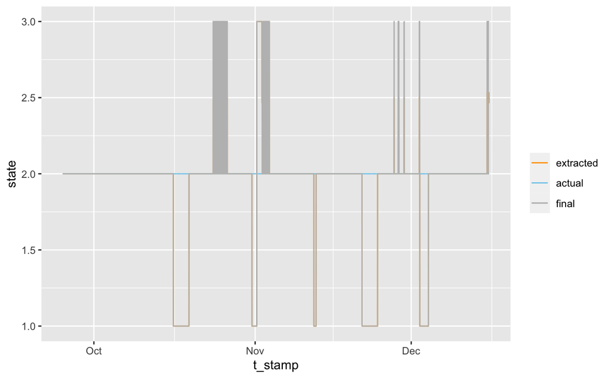

```r
df <- df %>%
  mutate(state_final = ifelse(t_stamp > ymd_hms("2021-09-25 07:15:00"), ceiling(state), state_actual))

df %>%
  filter(t_stamp > ymd_h("2021-09-25 0"), t_stamp < ymd_h("2021-12-31 0")) %>%
  ggplot() +
    geom_line(aes(x = t_stamp, y = state, colour = "extracted")) +
    geom_line(aes(x = t_stamp, y = state_actual, colour = "actual")) +
    geom_line(aes(x = t_stamp, y = state_final, colour = "final")) +
    scale_colour_manual("", breaks = c("extracted", "actual", "final"), values = c("orange", "skyblue", "grey"))
```

## Check congruency between extracted and actual state

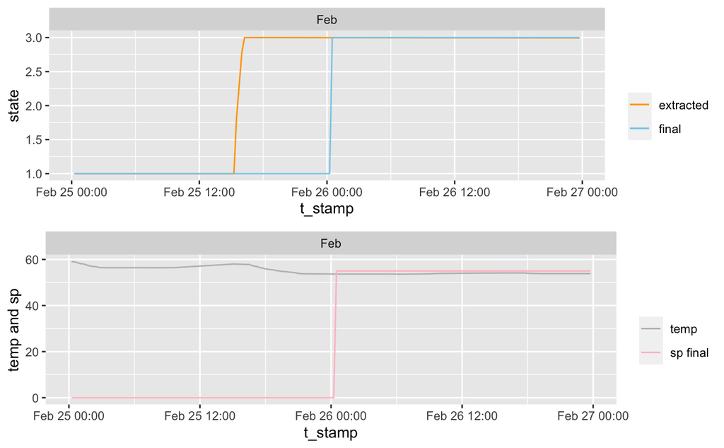

```r
feb_ex <- df %>%
  filter(t_stamp > ymd("2021-02-25"), t_stamp < ymd("2021-02-27"))

# feb_ex %>% View()

p1 <- feb_ex %>%
  ggplot() +
    geom_line(aes(x = t_stamp, y = state, colour = "extracted")) +
    # geom_line(aes(x = t_stamp, y = state_actual, colour = "actual")) +
    geom_line(aes(x = t_stamp, y = state_final, colour = "final")) +
    scale_colour_manual("", breaks = c("extracted", "final"), values = c("orange", "skyblue")) +
    ylab("state") +
    facet_wrap(vars(month), scales = "free_x")

p2 <- feb_ex %>%
  ggplot() +
    geom_line(aes(x = t_stamp, y = eng, colour = "temp")) +
    # geom_line(aes(x = t_stamp, y = sp_actual, colour = "sp" actual)) +
    geom_line(aes(x = t_stamp, y = sp_final, colour = "sp final")) +
    scale_colour_manual("", breaks = c("temp", "sp final"), values = c("grey", "pink")) +
    ylab("temp and sp") +
    facet_wrap(vars(month), scales = "free_x")

gridExtra::grid.arrange(p1, p2, nrow = 2)
```

```r
NA
NA
```

There’s a difference between extracted and final values in terms of when a state value got changed. Above Februrary example shows the extracted `state` to increase to 3 on Feb 25 at around 16:15pm and the final `state` to increase on Feb 26 at 0:30am.

I’m assuming the final `state` is correct, supported by the setpoint correlation.

Rename frame and columns and remove unnecessary cols for next script…

```r
df_d1_recoded <- df %>%
  select(
    t_stamp,
    year,
    month,
    day,
    wday,
    temp = eng,
    state_extracted = state,
    state_actual,
    state_final,
    sp_extracted = sp,
    sp_actual,
    sp_final
  )
```